# Project: Investigate a Dataset - [Medical Appointment No Shows]

- Introduction
- Data Wrangling
- Exploratory Data Analysis
- Conclusions

## Introduction

### Dataset Description

This dataset collects information from 100k medical appointments in Brazil and is focused on the question of whether or not patients show up for their appointment. A number of characteristics about the patient are included in each row.

- ‘ScheduledDay’: tells us on what day the patient set up their appointment.
- ‘Neighborhood’: indicates the location of the hospital.
- ‘Scholarship’: indicates whether or not the patient is enrolled in Brasilian welfare program Bolsa Família.
- For the last column [No_show]: it says ‘No’ if the patient showed up to their appointment, and ‘Yes’ if they did not show up.

### Questions posed ...

- what factors will determine if a patient will show up on their appointment ?
- what factors makes a patients not showing up for their invitation ?
- which columns are relevant for our analysis ?
- which of the neighbourhood showed up most for the invitations ?
- which among the newbourhood ignored the invitation most and why ?
- which AppointmentDay does patient tends to show up best for their invitation ?
- which scheduledday does a patient tends to show up best for thir invitation ?
- how do we improve the service such that a patient can easily show up for their invitation ?

#### importing parkages to be used for the analysis

```python
import pandas as pd
import numpy as np
import seaborn as sns
import warnings
warnings.filterwarnings("ignore")
import matplotlib.pyplot as plt
%matplotlib inline
pd.set_option("display.max_columns", None)
pd.set_option("display.max_rows", None)
```

## Data Wrangling

### Loading the dataset

```python
data = pd.read_csv("KaggleV2-May-2016.csv")
data.head() # displaying the first five rows
```

|  | PatientId | AppointmentID | Gender | ScheduledDay | AppointmentDay | Age | Neighbourhood | Scholarship | Hipertension | Diabetes | Alcoholism | Handcap | SMS_received | No-show |
| --- | --- | --- | --- | --- | --- | --- | --- | --- | --- | --- | --- | --- | --- | --- |
| 0 | 2.987250e+13 | 5642903 | F | 2016-04-29T18:38:08Z | 2016-04-29T00:00:00Z | 62 | JARDIM DA PENHA | 0 | 1 | 0 | 0 | 0 | 0 | No |
| 1 | 5.589978e+14 | 5642503 | M | 2016-04-29T16:08:27Z | 2016-04-29T00:00:00Z | 56 | JARDIM DA PENHA | 0 | 0 | 0 | 0 | 0 | 0 | No |
| 2 | 4.262962e+12 | 5642549 | F | 2016-04-29T16:19:04Z | 2016-04-29T00:00:00Z | 62 | MATA DA PRAIA | 0 | 0 | 0 | 0 | 0 | 0 | No |
| 3 | 8.679512e+11 | 5642828 | F | 2016-04-29T17:29:31Z | 2016-04-29T00:00:00Z | 8 | PONTAL DE CAMBURI | 0 | 0 | 0 | 0 | 0 | 0 | No |
| 4 | 8.841186e+12 | 5642494 | F | 2016-04-29T16:07:23Z | 2016-04-29T00:00:00Z | 56 | JARDIM DA PENHA | 0 | 1 | 1 | 0 | 0 | 0 | No |

### Data Cleaning

```python
print("\nChecking if they exist a null values in the dataset for all the columns\n--------------------------------")
data.isnull().sum()
#checking if there exist a null value present in any of the sample
```

```
Checking if they exist a null values in the dataset for all the columns
--------------------------------
```

```
PatientId         0
AppointmentID     0
Gender            0
ScheduledDay      0
AppointmentDay    0
Age               0
Neighbourhood     0
Scholarship       0
Hipertension      0
Diabetes          0
Alcoholism        0
Handcap           0
SMS_received      0
No-show           0
dtype: int64
```

### A funtion to check for the numerical variable present in the dataset

```python
def num_feat(data):
    for label, content in data.items():
        if pd.api.types.is_numeric_dtype(content):
#             if pd.isnull(content).sum():
                print(label)
num_feat(data)
```

```
PatientId
AppointmentID
Age
Scholarship
Hipertension
Diabetes
Alcoholism
Handcap
SMS_received
```

- there is no null value present in the dataset

### A funtion to check for the string variables

```python
print("The strings/object datatypes are\n------------------------")
def string_feat(data):
    for label, content  in data.items():
        if pd.api.types.is_string_dtype(content):
            print(label)
string_feat(data)
```

```
The strings/object datatypes are
------------------------
Gender
ScheduledDay
AppointmentDay
Neighbourhood
No-show
```

### A funtion to check for the categorical variables

```python
def cate_feat(data):
    print("the categorical features are \n")
    for label, content in data.items():
        if pd.api.types.is_categorical_dtype(content):
            print(label)
cate_feat(data)
```

```
the categorical features are
```

since there is no output above

- therefore they is not categorical feature present

```python
data.info()
```

```
<class 'pandas.core.frame.DataFrame'>
RangeIndex: 110527 entries, 0 to 110526
Data columns (total 14 columns):
 #   Column          Non-Null Count   Dtype
---  ------          --------------   -----
 0   PatientId       110527 non-null  float64
 1   AppointmentID   110527 non-null  int64
 2   Gender          110527 non-null  object
 3   ScheduledDay    110527 non-null  object
 4   AppointmentDay  110527 non-null  object
 5   Age             110527 non-null  int64
 6   Neighbourhood   110527 non-null  object
 7   Scholarship     110527 non-null  int64
 8   Hipertension    110527 non-null  int64
 9   Diabetes        110527 non-null  int64
 10  Alcoholism      110527 non-null  int64
 11  Handcap         110527 non-null  int64
 12  SMS_received    110527 non-null  int64
 13  No-show         110527 non-null  object
dtypes: float64(1), int64(8), object(5)
memory usage: 11.8+ MB
```

#### displaying littile information about the data

- number of data entries in the dataset
- number of columns and name
- number of non-null values present in each columns
- datatypes for all the columns

```python
data.describe()
```

|  | PatientId | AppointmentID | Age | Scholarship | Hipertension | Diabetes | Alcoholism | Handcap | SMS_received |
| --- | --- | --- | --- | --- | --- | --- | --- | --- | --- |
| count | 1.105270e+05 | 1.105270e+05 | 110527.000000 | 110527.000000 | 110527.000000 | 110527.000000 | 110527.000000 | 110527.000000 | 110527.000000 |
| mean | 1.474963e+14 | 5.675305e+06 | 37.088874 | 0.098266 | 0.197246 | 0.071865 | 0.030400 | 0.022248 | 0.321026 |
| std | 2.560949e+14 | 7.129575e+04 | 23.110205 | 0.297675 | 0.397921 | 0.258265 | 0.171686 | 0.161543 | 0.466873 |
| min | 3.921784e+04 | 5.030230e+06 | -1.000000 | 0.000000 | 0.000000 | 0.000000 | 0.000000 | 0.000000 | 0.000000 |
| 25% | 4.172614e+12 | 5.640286e+06 | 18.000000 | 0.000000 | 0.000000 | 0.000000 | 0.000000 | 0.000000 | 0.000000 |
| 50% | 3.173184e+13 | 5.680573e+06 | 37.000000 | 0.000000 | 0.000000 | 0.000000 | 0.000000 | 0.000000 | 0.000000 |
| 75% | 9.439172e+13 | 5.725524e+06 | 55.000000 | 0.000000 | 0.000000 | 0.000000 | 0.000000 | 0.000000 | 1.000000 |
| max | 9.999816e+14 | 5.790484e+06 | 115.000000 | 1.000000 | 1.000000 | 1.000000 | 1.000000 | 4.000000 | 1.000000 |

#### This is a simple statistical analysis showing the following details on the numeric samples

- count or each columns
- the mean of each columns
- the standard deviation for each sample column
- the minimum values for each of the columns
- the 25% percentile
- the 50% percentile
- 75% percentile
- and the maaximum values for each of the samples

### Checking for the number of rows and columns present in the dataset

```python
print("number of rows present in the dataset are: ")
print(data.shape[0])
print('number of columns present in the dataset are: ')
print(data.shape[1])
```

```
number of rows present in the dataset are:
110527
number of columns present in the dataset are:
14
```

```python
print("The patientid is a unique value assigned to each patient containing : ",data.PatientId.nunique(),"values\nTherefore we are dropping it off as it wont really have impact on our analysis")
print("Thesame thing applicable to AppointmentID")
data.drop(["PatientId","AppointmentID"], axis = 1, inplace = True)
```

```
The patientid is a unique value assigned to each patient containing :  62299 values
Therefore we are dropping it off as it wont really have impact on our analysis
Thesame thing applicable to AppointmentID
```

```python
data.columns
#checking the names of the columns in the dataset and as well its nature
```

```
Index(['Gender', 'ScheduledDay', 'AppointmentDay', 'Age', 'Neighbourhood',
       'Scholarship', 'Hipertension', 'Diabetes', 'Alcoholism', 'Handcap',
       'SMS_received', 'No-show'],
      dtype='object')
```

- From the above the above, the name No-show has a hyphen on it which is not a proper naming standard we we are going to change it to undrscore'_' and alse change all the table header to lowercase for easy access #### changing the names of the columns

```python
former_cols =  list(data.columns)
new_cols = []
for item in former_cols:
    col = item.lower().replace('-','_')
    new_cols.append(col)
print("THE NEW COLUMNS TO BE USED ARE\n-------------------------\n",new_cols)
```

```
THE NEW COLUMNS TO BE USED ARE
-------------------------
 ['gender', 'scheduledday', 'appointmentday', 'age', 'neighbourhood', 'scholarship', 'hipertension', 'diabetes', 'alcoholism', 'handcap', 'sms_received', 'no_show']
```

```python
data.columns = new_cols #assigning the new columns to our dataset
data.head()
```

|  | gender | scheduledday | appointmentday | age | neighbourhood | scholarship | hipertension | diabetes | alcoholism | handcap | sms_received | no_show |
| --- | --- | --- | --- | --- | --- | --- | --- | --- | --- | --- | --- | --- |
| 0 | F | 2016-04-29T18:38:08Z | 2016-04-29T00:00:00Z | 62 | JARDIM DA PENHA | 0 | 1 | 0 | 0 | 0 | 0 | No |
| 1 | M | 2016-04-29T16:08:27Z | 2016-04-29T00:00:00Z | 56 | JARDIM DA PENHA | 0 | 0 | 0 | 0 | 0 | 0 | No |
| 2 | F | 2016-04-29T16:19:04Z | 2016-04-29T00:00:00Z | 62 | MATA DA PRAIA | 0 | 0 | 0 | 0 | 0 | 0 | No |
| 3 | F | 2016-04-29T17:29:31Z | 2016-04-29T00:00:00Z | 8 | PONTAL DE CAMBURI | 0 | 0 | 0 | 0 | 0 | 0 | No |
| 4 | F | 2016-04-29T16:07:23Z | 2016-04-29T00:00:00Z | 56 | JARDIM DA PENHA | 0 | 1 | 1 | 0 | 0 | 0 | No |

```python
data["scheduledday"].nunique(), data['appointmentday'].nunique()
```

```
(103549, 27)
```

- this shows that in the "schoolday" column, the time attarched to it affeted the values negatively and has to be removed, so it won't appear as the PatientID & depertmentID which is a unique values attarched to each patient

### A funtion to strip off TIME from the Dates

- appointmentday
- scheduledday

```python
def date_(date):
    new_val = []
    for i in date:
        x = i[:-10]
        new_val.append(x)
    data['appointmentday'] = new_val
    return new_val[:4] # printing the first four values of the new date
date_(data['appointmentday'].values)
```

```
['2016-04-29', '2016-04-29', '2016-04-29', '2016-04-29']
```

```python
def date_(date):
    new_val = []
    for i in date:
        x = i[:-10]
        new_val.append(x)
    data['scheduledday'] = new_val
    return new_val[:4] # printing the first four values of the new date
date_(data['scheduledday'].values)
```

```
['2016-04-29', '2016-04-29', '2016-04-29', '2016-04-29']
```

```python
data.head()
```

|  | gender | scheduledday | appointmentday | age | neighbourhood | scholarship | hipertension | diabetes | alcoholism | handcap | sms_received | no_show |
| --- | --- | --- | --- | --- | --- | --- | --- | --- | --- | --- | --- | --- |
| 0 | F | 2016-04-29 | 2016-04-29 | 62 | JARDIM DA PENHA | 0 | 1 | 0 | 0 | 0 | 0 | No |
| 1 | M | 2016-04-29 | 2016-04-29 | 56 | JARDIM DA PENHA | 0 | 0 | 0 | 0 | 0 | 0 | No |
| 2 | F | 2016-04-29 | 2016-04-29 | 62 | MATA DA PRAIA | 0 | 0 | 0 | 0 | 0 | 0 | No |
| 3 | F | 2016-04-29 | 2016-04-29 | 8 | PONTAL DE CAMBURI | 0 | 0 | 0 | 0 | 0 | 0 | No |
| 4 | F | 2016-04-29 | 2016-04-29 | 56 | JARDIM DA PENHA | 0 | 1 | 1 | 0 | 0 | 0 | No |

```python
data["scheduledday"].nunique(), data['appointmentday'].nunique()
```

```
(111, 27)
```

- The above shows that the date is now well formatted and ready for analysis

### checking for Duplicate values

```python
duplicate = data.duplicated().sum()
print("There are: ", duplicate, "values")
```

```
There are:  8070 values
```

```python
# dropping duplicates
data.drop_duplicates(inplace = True)
```

```python
# checking to confirm if the duplicated values has been dropped
data.duplicated().sum()
```

```
0
```

```python
data.appointmentday.unique()
```

```
array(['2016-04-29', '2016-05-03', '2016-05-10', '2016-05-17',
       '2016-05-24', '2016-05-31', '2016-05-02', '2016-05-30',
       '2016-05-16', '2016-05-04', '2016-05-19', '2016-05-12',
       '2016-05-06', '2016-05-20', '2016-05-05', '2016-05-13',
       '2016-05-09', '2016-05-25', '2016-05-11', '2016-05-18',
       '2016-05-14', '2016-06-02', '2016-06-03', '2016-06-06',
       '2016-06-07', '2016-06-01', '2016-06-08'], dtype=object)
```

```python
data.scheduledday.nunique()
```

```
111
```

### checking for outliars in the age columns

```python
data[data['age'] <0]
```

[output not shown]

the above shows that they exits outliers in the female gender...

- since nobody's age is less than 1

### droping outliers in the age columns

```python
data.drop(data[data['age'] < 0].index, inplace = True)
data[data['age'] < 0] # confirming if the outlier has been dropped off
```

|  | gender | scheduledday | appointmentday | age | neighbourhood | scholarship | hipertension | diabetes | alcoholism | handcap | sms_received | no_show |
| --- | --- | --- | --- | --- | --- | --- | --- | --- | --- | --- | --- | --- |

# Exploratory Data Analysis (EDA)

- ### How does each of the samples affect the No_show ?
  - the relationship between each of the samples
  - what sample is said to be dropped
  - What are the correlation of the samples
- ### What age range is more likely to show up ?
  - how does age affect the no show and other variaable
- ### At what year do we have the highest sho up ?

# What are the relationship between each of the samples ?

- using the groupby funtion and matplotlib to find the correlation between each of the sample pairs

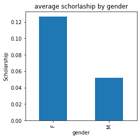

```python
data.groupby("gender").scholarship.mean().plot(kind = "bar", figsize = (4,4),
                                               title = "average schorlaship by gender", ylabel = "Scholarship");
```

the above chart shows that females tends to have more scholarship oppertunities than the male

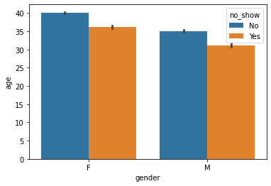

```python
sns.barplot(x ='gender' , y ='age' , hue= 'no_show', data= data);
```

A graph plot of gender and age with respect it how they showed up to their apintment

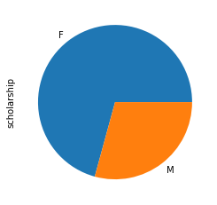

```python
data.groupby("gender").scholarship.mean().plot(kind = 'pie');
```

### showing the No_show distribution/respone counts (Yes and No)

- we have a larger population in with No than that of Yes
- which means that higher percentage of patients actually show up for the appointment

```python
data.no_show.value_counts()
```

```
No     80950
Yes    21507
Name: no_show, dtype: int64
```

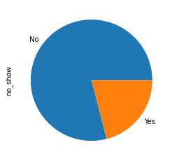

```python
data.no_show.value_counts().plot(kind = 'pie');
```

here we have a Higher population of patients who showed up for their appointment

- No: means (showed up)
- Yes: means (didn't show up)

#### changing the values of the no show columns from NO & YES to 1 & 0

- this will as well help to check for the correlation of the samples

```python
data['no_show'] = data['no_show'].replace(['No', 'Yes'], [0, 1])
data.head(2) # printing the first two rows
```

|  | gender | scheduledday | appointmentday | age | neighbourhood | scholarship | hipertension | diabetes | alcoholism | handcap | sms_received | no_show |
| --- | --- | --- | --- | --- | --- | --- | --- | --- | --- | --- | --- | --- |
| 0 | F | 2016-04-29 | 2016-04-29 | 62 | JARDIM DA PENHA | 0 | 1 | 0 | 0 | 0 | 0 | 0 |
| 1 | M | 2016-04-29 | 2016-04-29 | 56 | JARDIM DA PENHA | 0 | 0 | 0 | 0 | 0 | 0 | 0 |

The Fmale had more scholarship opportunities than the male

## The correlation of Samples and No-Show

Correlation ranges from -1 to +1. Values closer to zero means there is no linear trend between the two variables. The close to 1 the correlation is the more positively correlated they are; that is as one increases so does the other and the closer to 1 the stronger this relationship is.

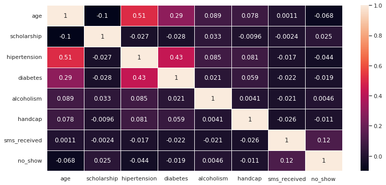

```python
data['no_show'].replace(['No', 'Yes'], [0, 1])
sns.set(rc = {'figure.figsize':(13,6)})
sns.heatmap(data.corr(),
        xticklabels=data.corr().columns,
        yticklabels=data.corr().columns,
            annot = True, linewidths=.9)

plt.show()
```

```python
cmap = cmap=sns.diverging_palette(5, 250, as_cmap=True)

def magnify():
    return [dict(selector="tf",
                 props=[("font-size", "7pt")]),
            dict(selector="td",
                 props=[('padding', "0em 0em")]),
            dict(selector="th:hover",
                 props=[("font-size", "12pt")]),
            dict(selector="tr:hover td:hover",
                 props=[('max-width', '200px'),
                        ('font-size', '12pt')])
]

data.corr().style.background_gradient(cmap, axis=1)\
    .set_properties(**{'max-width': '80px', 'font-size': '10pt'})\
    .set_caption("Hover to magify")\
    .set_precision(2)\
    .set_table_styles(magnify())
```

Hover to magify

|  | age | scholarship | hipertension | diabetes | alcoholism | handcap | sms_received | no_show |
| --- | --- | --- | --- | --- | --- | --- | --- | --- |
| age | 1.00 | -0.10 | 0.51 | 0.29 | 0.09 | 0.08 | 0.00 | -0.07 |
| scholarship | -0.10 | 1.00 | -0.03 | -0.03 | 0.03 | -0.01 | -0.00 | 0.03 |
| hipertension | 0.51 | -0.03 | 1.00 | 0.43 | 0.08 | 0.08 | -0.02 | -0.04 |
| diabetes | 0.29 | -0.03 | 0.43 | 1.00 | 0.02 | 0.06 | -0.02 | -0.02 |
| alcoholism | 0.09 | 0.03 | 0.08 | 0.02 | 1.00 | 0.00 | -0.02 | 0.00 |
| handcap | 0.08 | -0.01 | 0.08 | 0.06 | 0.00 | 1.00 | -0.03 | -0.01 |
| sms_received | 0.00 | -0.00 | -0.02 | -0.02 | -0.02 | -0.03 | 1.00 | 0.12 |
| no_show | -0.07 | 0.03 | -0.04 | -0.02 | 0.00 | -0.01 | 0.12 | 1.00 |

```
% 0f Distribution of Scholarship against No-Show
 -----------------------------------------

no_show
0     9.689932
1    11.540429
Name: scholarship, dtype: float64
```

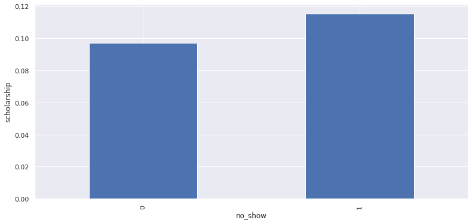

```python
print("% 0f Distribution of Scholarship against No-Show\n -----------------------------------------\n")
print(data.groupby("no_show").scholarship.mean()*100)
data.groupby("no_show").scholarship.mean().plot(kind ="bar", ylabel = "scholarship");
```

##### This shows that the availability of scholarship tends to Decrease the rate of patients showing up for their appointment

since the people without scholarship tends to have showed up for their apointment than others

- 0 means (showed up)
- 1 means (didn't show up)

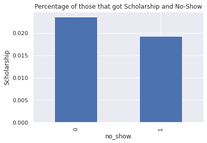

```python
data.groupby("no_show").handcap.mean().plot(kind= "bar", figsize = (6,4),
                                                     title = "Percentage of those that got Scholarship and No-Show", ylabel = "Scholarship");
```

```
from the above it is seen that
SÃO BENEDITO  had more schorlaship than others :  0.27978883861236803
followed by DON MOSCOSO
```

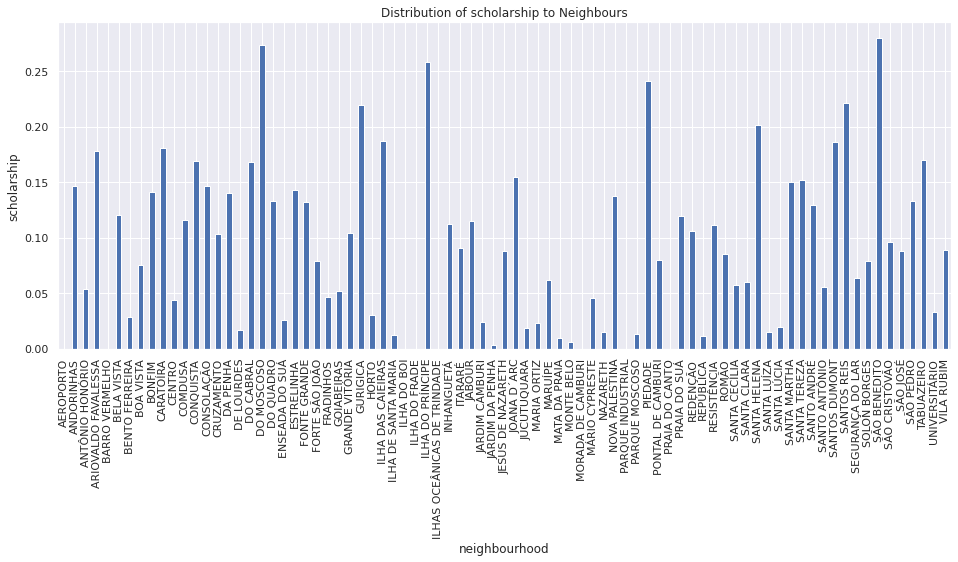

```python
schor_Neigh_dist = data.groupby("neighbourhood").mean().scholarship
print("from the above it is seen that\nSÃO BENEDITO  had more schorlaship than others : ", max(schor_Neigh_dist), "\nfollowed by DON MOSCOSO")
schor_Neigh_dist.plot(kind = "bar", figsize = (16,6), title = "Distribution of scholarship to Neighbours", ylabel = "scholarship");
```

```python
data.neighbourhood.nunique()
```

```
81
```

#### Among the 81 neighbourhood, from the analysis in the cell bellow

- JARDIM CAMBURI has the highest population of people that showed up for the invitation
- JARDIM CAMBURI also has the highest population of people that didn't show up for the invitation

##### checking for the neighbourhood that didn't show up most for their invitation

```python
def neighb(val):
    x = val.neighbourhood.unique()
    Density = []
    print("THE NUMBER OF NEIGHBOURHOOD THAT SHOWED UP FOR THEIR INVITATIO\n")
    for i in x:
        density = data.query("neighbourhood == '{}' and no_show == 1".format(i)).shape[0]
        Density.append(density)
        print(i,"<----------------->",density)
    print(max(Density))
neighb(data)
```

```
THE NUMBER OF NEIGHBOURHOOD THAT SHOWED UP FOR THEIR INVITATIO

JARDIM DA PENHA <-----------------> 619
MATA DA PRAIA <-----------------> 108
PONTAL DE CAMBURI <-----------------> 12
REPÚBLICA <-----------------> 140
GOIABEIRAS <-----------------> 133
ANDORINHAS <-----------------> 487
CONQUISTA <-----------------> 153
NOVA PALESTINA <-----------------> 394
DA PENHA <-----------------> 424
TABUAZEIRO <-----------------> 558
BENTO FERREIRA <-----------------> 182
SÃO PEDRO <-----------------> 494
SANTA MARTHA <-----------------> 478
SÃO CRISTÓVÃO <-----------------> 356
MARUÍPE <-----------------> 413
GRANDE VITÓRIA <-----------------> 213
SÃO BENEDITO <-----------------> 258
ILHA DAS CAIEIRAS <-----------------> 230
SANTO ANDRÉ <-----------------> 476
SOLON BORGES <-----------------> 69
BONFIM <-----------------> 536
JARDIM CAMBURI <-----------------> 1387
MARIA ORTIZ <-----------------> 1174
JABOUR <-----------------> 449
ANTÔNIO HONÓRIO <-----------------> 49
RESISTÊNCIA <-----------------> 876
ILHA DE SANTA MARIA <-----------------> 355
JUCUTUQUARA <-----------------> 132
MONTE BELO <-----------------> 165
MÁRIO CYPRESTE <-----------------> 52
SANTO ANTÔNIO <-----------------> 467
BELA VISTA <-----------------> 368
PRAIA DO SUÁ <-----------------> 291
SANTA HELENA <-----------------> 37
ITARARÉ <-----------------> 885
INHANGUETÁ <-----------------> 200
UNIVERSITÁRIO <-----------------> 32
SÃO JOSÉ <-----------------> 394
```

[output cut: 29 more lines]

```
COMDUSA <-----------------> 53
SANTA CECÍLIA <-----------------> 121
VILA RUBIM <-----------------> 139
DE LOURDES <-----------------> 47
DO QUADRO <-----------------> 131
DO CABRAL <-----------------> 84
HORTO <-----------------> 41
SEGURANÇA DO LAR <-----------------> 27
ILHA DO BOI <-----------------> 3
FRADINHOS <-----------------> 48
NAZARETH <-----------------> 29
AEROPORTO <-----------------> 1
ILHAS OCEÂNICAS DE TRINDADE <-----------------> 2
PARQUE INDUSTRIAL <-----------------> 0
1387
```

##### checking for the neighbourhood that showed up most for their invitation

```python
def neighb(val):
    x = val.neighbourhood.unique()
    Density = []
    print("THE NUMBER OF NEIGHBOURHOOD THAT SHOWED UP FOR THEIR INVITATIO\n")
    for i in x:
        density = data.query("neighbourhood == '{}' and no_show == 0".format(i)).shape[0]
        Density.append(density)
        print(i,"<----------------->",density)
    print(max(Density))
neighb(data)
```

```
THE NUMBER OF NEIGHBOURHOOD THAT SHOWED UP FOR THEIR INVITATIO

JARDIM DA PENHA <-----------------> 2957
MATA DA PRAIA <-----------------> 510
PONTAL DE CAMBURI <-----------------> 51
REPÚBLICA <-----------------> 650
GOIABEIRAS <-----------------> 548
ANDORINHAS <-----------------> 1617
CONQUISTA <-----------------> 652
NOVA PALESTINA <-----------------> 1712
DA PENHA <-----------------> 1642
TABUAZEIRO <-----------------> 2415
BENTO FERREIRA <-----------------> 616
SÃO PEDRO <-----------------> 1800
SANTA MARTHA <-----------------> 2361
SÃO CRISTÓVÃO <-----------------> 1422
MARUÍPE <-----------------> 1413
GRANDE VITÓRIA <-----------------> 823
SÃO BENEDITO <-----------------> 1068
ILHA DAS CAIEIRAS <-----------------> 795
SANTO ANDRÉ <-----------------> 1879
SOLON BORGES <-----------------> 385
BONFIM <-----------------> 2006
JARDIM CAMBURI <-----------------> 5243
MARIA ORTIZ <-----------------> 3932
JABOUR <-----------------> 1886
ANTÔNIO HONÓRIO <-----------------> 210
RESISTÊNCIA <-----------------> 3127
ILHA DE SANTA MARIA <-----------------> 1388
JUCUTUQUARA <-----------------> 510
MONTE BELO <-----------------> 640
MÁRIO CYPRESTE <-----------------> 276
SANTO ANTÔNIO <-----------------> 2090
BELA VISTA <-----------------> 1414
PRAIA DO SUÁ <-----------------> 963
SANTA HELENA <-----------------> 137
ITARARÉ <-----------------> 2400
INHANGUETÁ <-----------------> 797
UNIVERSITÁRIO <-----------------> 119
SÃO JOSÉ <-----------------> 1433
```

[output cut: 29 more lines]

```
COMDUSA <-----------------> 241
SANTA CECÍLIA <-----------------> 318
VILA RUBIM <-----------------> 695
DE LOURDES <-----------------> 250
DO QUADRO <-----------------> 690
DO CABRAL <-----------------> 453
HORTO <-----------------> 125
SEGURANÇA DO LAR <-----------------> 114
ILHA DO BOI <-----------------> 32
FRADINHOS <-----------------> 209
NAZARETH <-----------------> 105
AEROPORTO <-----------------> 7
ILHAS OCEÂNICAS DE TRINDADE <-----------------> 0
PARQUE INDUSTRIAL <-----------------> 1
5243
```

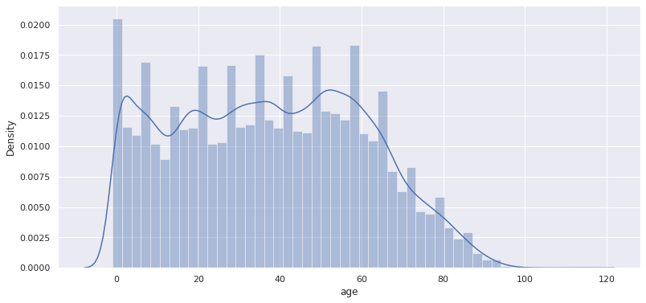

```python
sns.distplot(data.age);
```

```
------------------age distribution-------
```

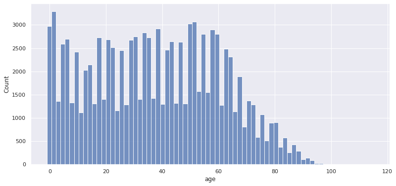

```python
print("\n------------------age distribution-------")
sns.histplot(data.age);
```

this is a histogram showing a clearer distribution of the age column counts

# checking for the distribution of samples in each of the columns.

### creating a bar, pie, dist and line chart for the value counts

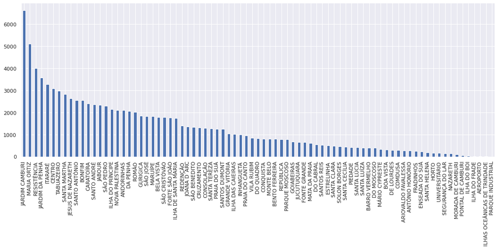

```python
data.neighbourhood.value_counts().plot(kind = "bar", figsize = (18,6));
```

```python
appointment = data.groupby("appointmentday").mean()
```

```python
appointment = data.groupby("appointmentday").mean().no_show
```

## Below is the plot for the density of no_show with respect to appointment day

- from the chart below, the highest density was recorded on **2016-05-20**
- 2016-05-20 : **0.24089**
- #### folowed by
- 2016-05-04 : **0.23872** and 2016-05-10 : **023796** etc

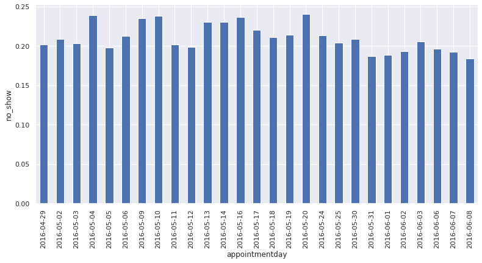

```python
appointment.plot(kind = "bar", ylabel = "no_show");
```

```python
scheduledday = data.groupby("scheduledday").mean()
```

```python
data.groupby("scheduledday").mean().no_show.mean()
```

```
0.2585919673011959
```

```python
scheduledday_half = data.groupby("scheduledday").mean()[:52].no_show
```

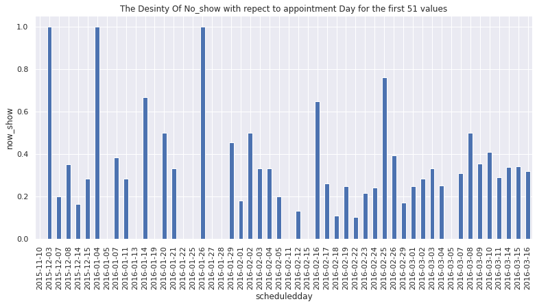

```python
scheduledday_half.plot(kind= "bar", ylabel = "now_show", title = "The Desinty Of No_show with repect to appointment Day for the first 51 values");
```

```python
scheduledday_half_2 = data.groupby("scheduledday").mean().no_show[51:]
```

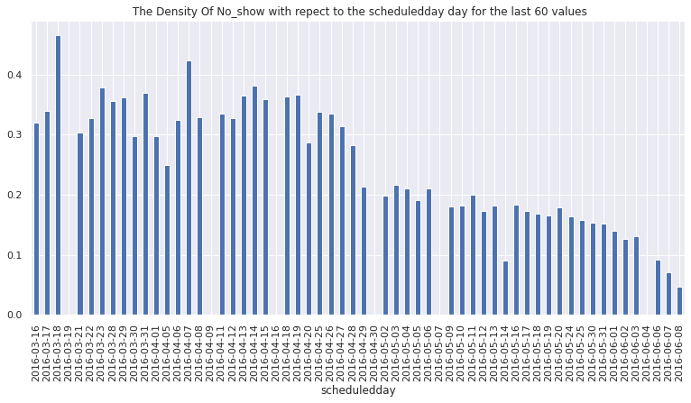

```python
scheduledday_half_2.plot(kind= "bar", title = " The Density Of No_show with repect to the scheduledday day for the last 60 values");
```

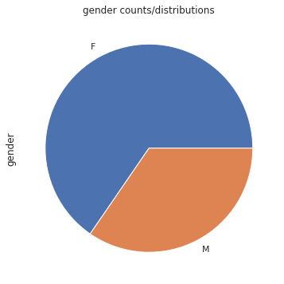

```python
data.gender.value_counts().plot(kind = "pie", title = "gender counts/distributions");
```

this shows that we have more of the faminine gender than that of the male

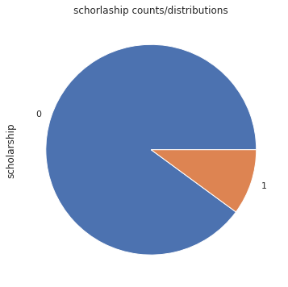

```python
data.scholarship.value_counts().plot(kind = "pie", title = "schorlaship counts/distributions");
```

the pie chart shows that we tend to have less scholarship opportunity

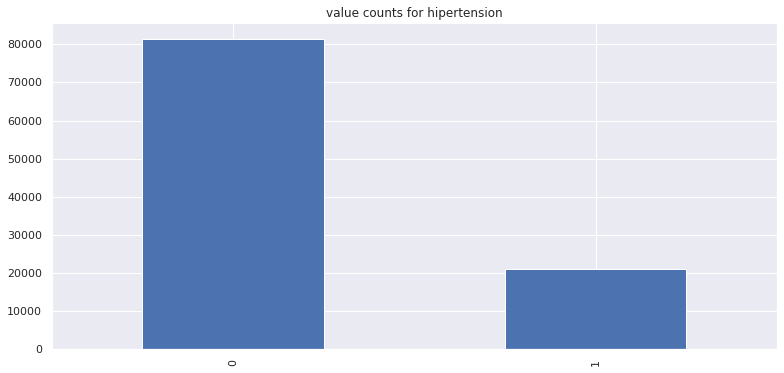

```python
data.hipertension.value_counts().plot(kind = "bar", title  = 'value counts for hipertension');
```

this shows that few number of the patients has hipertension

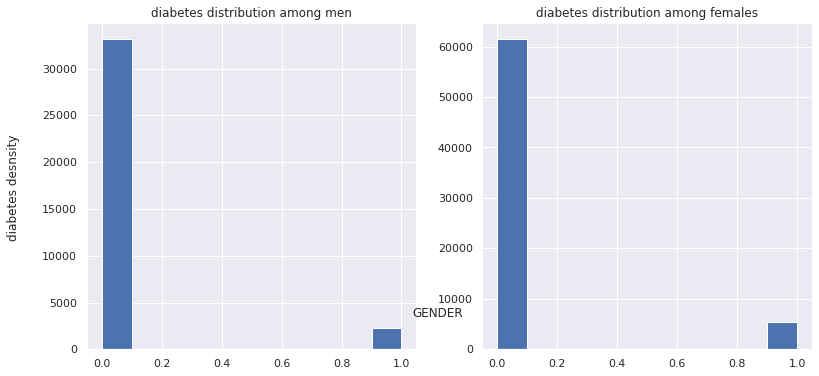

```python
fig, axes = plt.subplots(1,2)

data.diabetes[data.gender == 'M'].hist(label = 'showed up', ax = axes[0])
data.diabetes[data.gender == 'F'].hist(label = 'showed up', ax = axes[1])

axes[0].set_title("diabetes distribution among men")
axes[1].set_title("diabetes distribution among females");

fig.text(0.5, 0.2, "GENDER", ha = 'center');
fig.text(0.04, 0.5, 'diabetes desnsity', va = 'center', rotation = 'vertical');
```

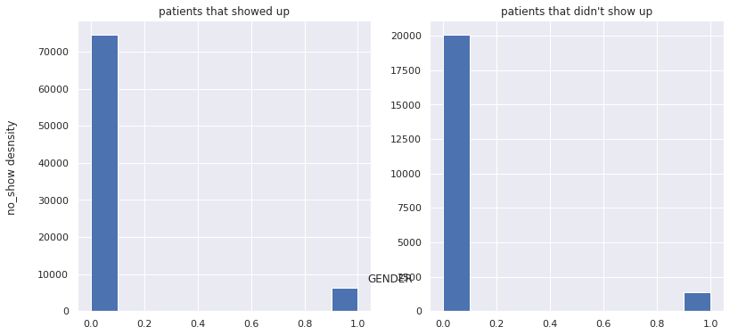

```python
fig, axes = plt.subplots(1,2)

data.diabetes[data.no_show == 0].hist(label = 'showed up', ax = axes[0])
data.diabetes[data.no_show == 1].hist(label = 'showed up', ax = axes[1])

axes[0].set_title("patients that showed up")
axes[1].set_title("patients that didn't show up");

fig.text(0.5, 0.2, "GENDER", ha = 'center');
fig.text(0.04, 0.5, 'no_show desnsity', va = 'center', rotation = 'vertical');
```

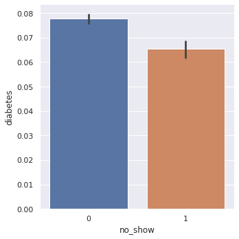

```python
# data.diabetes.value_counts().plot(kind = "line",color = "r", title = "values counts for diabetes" );
sns.catplot(x="no_show", y="diabetes", kind = "bar", data=data);
```

this shows that few number of patients has diabetes

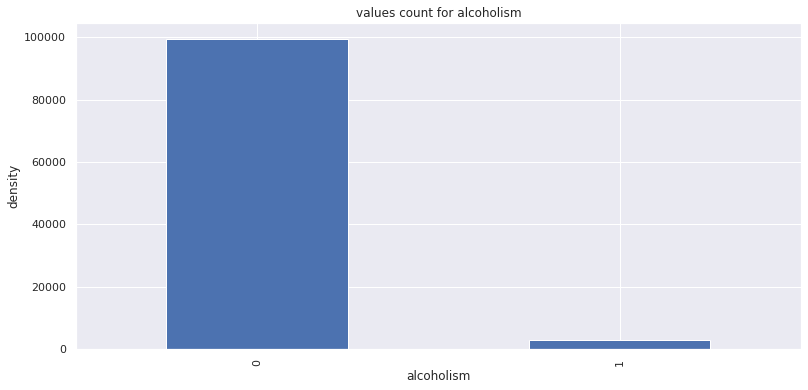

```python
data.alcoholism.value_counts().plot(kind = "bar", title = "values count for alcoholism", ylabel = "density", xlabel = "alcoholism");
```

this shows that fewer number of patients takes alcohol

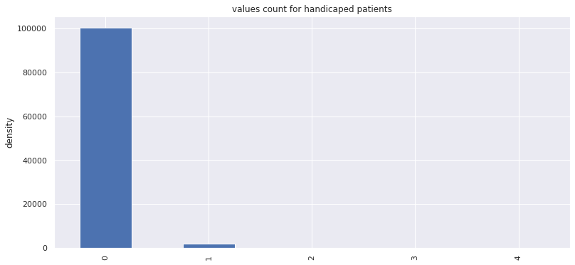

```python
data.handcap.value_counts().plot(kind = "bar", title = "values count for handicaped patients", ylabel = "density");
```

this shows that a very small fraction of the patients are handicaped

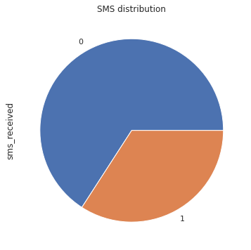

```python
data.sms_received.value_counts().plot(kind = "pie", title = "SMS distribution");
```

this shows that few people actually got the invitation sms

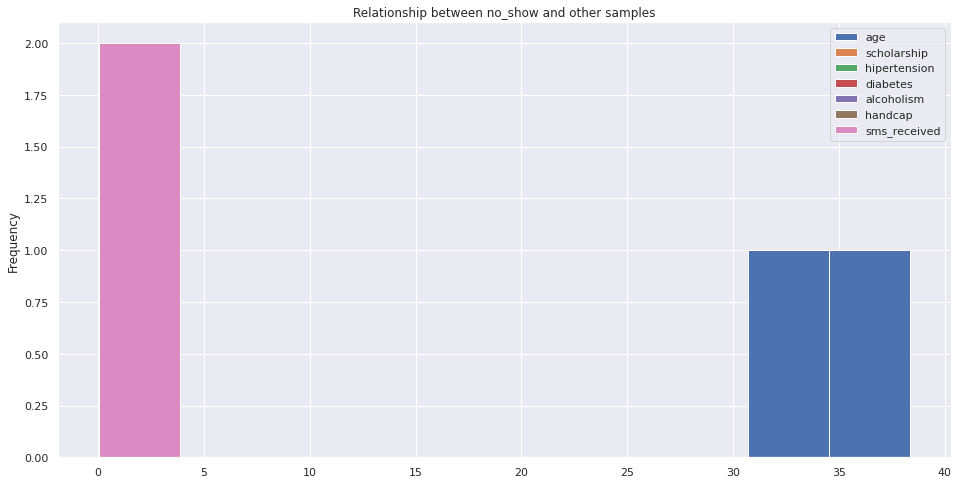

```python
data.groupby("no_show").mean().plot(kind= "hist", figsize = (16,8), title = "Relationship between no_show and other samples");
```

```python
print("THE IS THE  PERCENTAGE OF SMS DISTRIBUTIONS AMONG NEIGHBOURHOOD")
data.groupby("sms_received").neighbourhood.value_counts()
```

```
THE IS THE  PERCENTAGE OF SMS DISTRIBUTIONS AMONG NEIGHBOURHOOD
```

```
sms_received  neighbourhood
0             JARDIM CAMBURI                 4180
              MARIA ORTIZ                    3066
              RESISTÊNCIA                    2523
              JARDIM DA PENHA                2176
              ITARARÉ                        2155
              SANTA MARTHA                   2038
              TABUAZEIRO                     2022
              CENTRO                         2006
              CARATOÍRA                      1869
              JESUS DE NAZARETH              1843
              BONFIM                         1767
              SANTO ANTÔNIO                  1758
              SÃO PEDRO                      1609
              ANDORINHAS                     1539
              SANTO ANDRÉ                    1520
              NOVA PALESTINA                 1516
              DA PENHA                       1463
              JABOUR                         1433
              ILHA DO PRÍNCIPE               1420
              GURIGICA                       1350
              ROMÃO                          1254
              BELA VISTA                     1208
              MARUÍPE                        1184
              SÃO JOSÉ                       1170
              FORTE SÃO JOÃO                 1159
              SÃO CRISTÓVÃO                  1134
              ILHA DE SANTA MARIA            1086
              SÃO BENEDITO                    967
              CONSOLAÇÃO                      955
              JOANA D´ARC                     929
              REDENÇÃO                        908
              CRUZAMENTO                      811
              SANTA TEREZA                    801
              SANTOS DUMONT                   797
              PRAIA DO SUÁ                    735
              GRANDE VITÓRIA                  719
              ILHA DAS CAIEIRAS               690
              INHANGUETÁ                      616
              PRAIA DO CANTO                  603
```

[output cut: 107 more lines]

```
              ENSEADA DO SUÁ                   98
              ANTÔNIO HONÓRIO                  93
              MÁRIO CYPRESTE                   85
              SANTA HELENA                     69
              NAZARETH                         60
              ARIOVALDO FAVALESSA              57
              HORTO                            56
              SEGURANÇA DO LAR                 54
              UNIVERSITÁRIO                    54
              MORADA DE CAMBURI                41
              PONTAL DE CAMBURI                24
              ILHA DO BOI                       7
              ILHA DO FRADE                     6
              AEROPORTO                         1
Name: neighbourhood, dtype: int64
```

THE ABOVE SHOWS WHY **JARDIM CAMBURI** HAS THE HIGHEST POPULATION ON THE PATIENTS THAT SHOWED UP FOR THE INVITATION

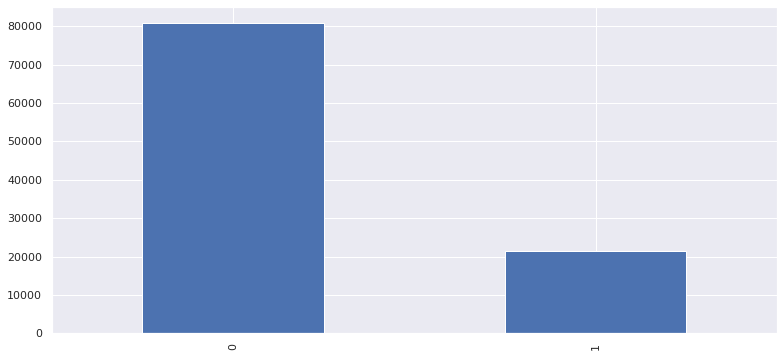

```python
data["no_show"].value_counts().plot(kind = "bar");
```

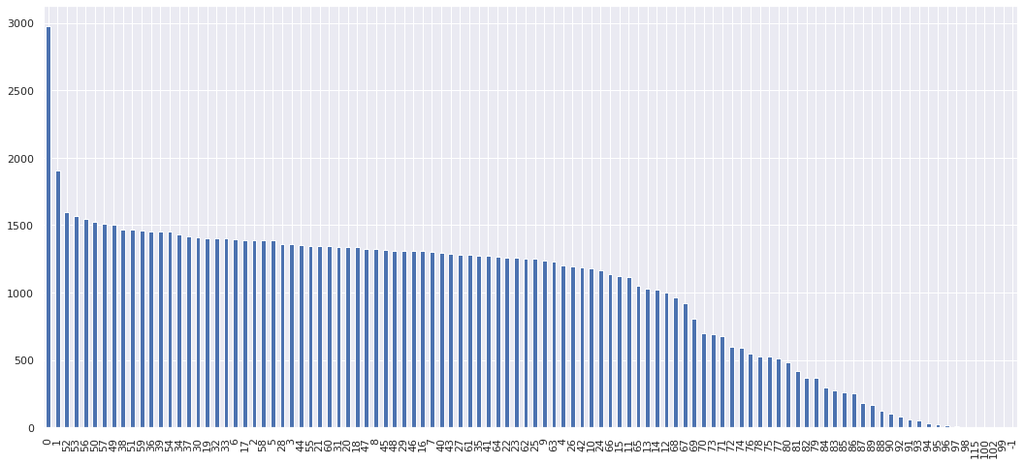

```python
data["age"].value_counts().plot(kind = "bar", figsize = (18,8));
```